# Lab 8

STAT 359 Data Visualization

# Overview

The goal of this lab is to begin setting the stage for data wranging (a skill which is REQUIRED for real-life analysis and data visualization) and begin combining the data visualization components which have been introduced over the previous weeks.

# Datasets

The ramen-ratings.csv is from Kaggle (https://www.kaggle.com/residentmario/ramen-ratings).

Per the website:

Each record in the dataset is a single ramen product review. Review numbers are contiguous: more recently reviewed ramen varieties have higher numbers. Brand, Variety (the product name), Country, and Style (Cup? Bowl? Tray?) are pretty self-explanatory. Stars indicate the ramen quality, as assessed by the reviewer, on a 5-point scale; this is the most important column in the dataset!

The meets.csv and openpowerlifiting.csv files are also from Kaggle (https://www.kaggle.com/open-powerlifting/powerlifting-database).

Per the website:

This dataset is a snapshot of the OpenPowerlifting database as of February 2018. OpenPowerlifting is an organization which tracks meets and competitor results in the sport of powerlifting, in which competitors complete to lift the most weight for their class in three separate weightlifting categories.

# Task

Run the provided R code, just below, prior to completing the tasks.

Note: all visualizations below must have a distinct theme (to put another way, all visualizations must have a theme and no two visualizations can share the same theme). The themes do not need to match exactly those in the solution.

```r
# Import libraries
library(tidyverse)
library(ggthemes)

# Import data
ramen_ratings_data <- read_csv('ramen-ratings.csv') %>%
  filter(Stars != 'Unrated',
         !Style %in% c('Bar', 'Box', 'Can', NA)) %>%
  separate(`Top Ten`, sep = '\\s', into = c('Year', 'Rank')) %>%
  mutate(Stars = as.double(Stars),
         Style = factor(Style),
         Year = as.integer(Year))

# Create a data set containing only observations with a rank
top_ranked <- filter(ramen_ratings_data, !is.na(Rank), !is.na(Year))

# Create a summarised version of the raw data, by country
country_ratings <- ramen_ratings_data %>%
  group_by(Country) %>%
  summarise(count = n(),
            median = median(Stars),
            mean = mean(Stars),
            max = max(Stars),
            min(Stars))

# Create a data set containing the names of the countries with the most reviews
most_reviewed_countries <- country_ratings %>%
  arrange(desc(count)) %>%
  head() %>%
  select(Country)

# Examine the dimensions of the raw data
dim(ramen_ratings_data)
```

```
## [1] 2567    8
```

```r
# Examine the raw data
head(ramen_ratings_data)
```

```
## # A tibble: 6 x 8
##   `Review #` Brand    Variety              Style Country Stars  Year Rank
##        <int> <chr>    <chr>                <fct> <chr>   <dbl> <int> <chr>
## 1       2580 New Tou… T's Restaurant Tant… Cup   Japan    3.75    NA <NA>
## 2       2579 Just Way Noodles Spicy Hot S… Pack  Taiwan   1       NA <NA>
## 3       2578 Nissin   Cup Noodles Chicken… Cup   USA      2.25    NA <NA>
## 4       2577 Wei Lih  GGE Ramen Snack Tom… Pack  Taiwan   2.75    NA <NA>
## 5       2576 Ching's… Singapore Curry      Pack  India    3.75    NA <NA>
## 6       2575 Samyang… Kimchi song Song Ra… Pack  South …  4.75    NA <NA>
```

0a. Briefly describe a dataframe? What do the rows represent in a dataframe? What about the columns? (hint: Google “what is a dataframe in R”)

`A table or 2-dimensional representation data where rows represent observations and columns represent charactertics of each observation (i.e. variables).`

0b. Below is an example dataframe (a tibble is a specific implementation of a dataframe).

Read this: http://r4ds.had.co.nz/tibbles.html

```r
employee_data <- tibble(
     emp_id = seq(5),
     emp_name = c("Xi","Hector","Sandy","Shaquille","Emily"),
     salary = c(40, 45, 70, 60, 35),
     isManager = c(FALSE, FALSE, TRUE, FALSE, FALSE)
   )

head(employee_data)
```

```
## # A tibble: 5 x 4
##   emp_id emp_name  salary isManager
##    <int> <chr>      <dbl> <lgl>
## 1      1 Xi            40 FALSE
## 2      2 Hector        45 FALSE
## 3      3 Sandy         70 TRUE
## 4      4 Shaquille     60 FALSE
## 5      5 Emily         35 FALSE
```

0c. Create a tibble called student_data with the following variables and display its top five rows:

`student_id`: a series of numbers from 1 to 5 `student_name`: a list of 5 names `understands_dataframes`: a list of 5 boolean values (i.e. TRUE or FALSE is a boolean value) `grade`: a list of 5 integers (presumably, those students who have a FALSE value for understands_dataframes get very low grades… in life)

```r
student_data <- tibble(
     student_id = seq(5),
     student_name = c("Master Shake", "Frylock", "Carl", "Meatwad", "Err"),
     understands_dataframe = c(FALSE, FALSE, FALSE, TRUE, FALSE),
     grade = c(15, 0, 80, 100, 72)
   )

head(student_data)
```

```
## # A tibble: 5 x 4
##   student_id student_name understands_dataframe grade
##        <int> <chr>        <lgl>                 <dbl>
## 1          1 Master Shake FALSE                    15
## 2          2 Frylock      FALSE                     0
## 3          3 Carl         FALSE                    80
## 4          4 Meatwad      TRUE                    100
## 5          5 Err          FALSE                    72
```

1a. Recreate the visualization below.

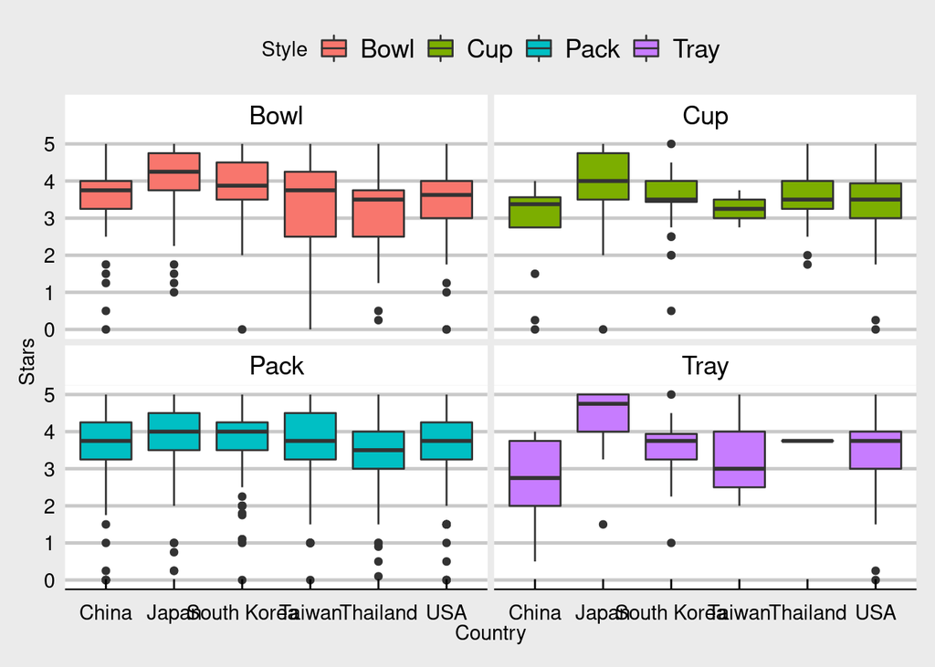

```r
ggplot(filter(ramen_ratings_data, Country %in% most_reviewed_countries$Country),
       aes(Country, Stars, fill = Style)) +
  geom_boxplot() +
  facet_wrap(~ Style) +
  theme_economist_white()
```

`The filter function is limiting the countries in the data to only those countries which also exist within the "Most Reviewed" data set.`

Run the provided R code, just below, prior to completing the tasks.

```r
library(lubridate)

competition_metadata <- read_csv('meets.csv') %>%
  mutate(Year = year(Date),
   Month = month(Date)) %>%
  select(-MeetPath)

individual_results <- read_csv('openpowerlifting.csv', guess_max = 40000) %>%
  mutate(Sex = factor(Sex),
         Equipment = factor(Equipment),
         isTopThreePlace = ifelse(Place %in% c('1', '2','3'), TRUE, FALSE),
         Age_Bin = case_when(Age < 20 ~ '< 20',
                             Age >= 20 & Age < 30 ~ '20 - 30',
                             Age >= 30 & Age < 40 ~ '30 - 40',
                             Age >= 40 & Age < 50 ~ '40 - 50',
                             Age >= 50 ~ '> 50')) %>%
  filter(BestSquatKg >= 0, BestDeadliftKg >= 0, BestBenchKg >= 0) %>%
  select(-Squat4Kg, -Bench4Kg, -Deadlift4Kg, -Wilks) %>%
  drop_na()

combined_data <- left_join(individual_results, competition_metadata, by = c('MeetID'))

top3_placement <- filter(combined_data, isTopThreePlace == TRUE)
```

2a. Recreate the below visualization.

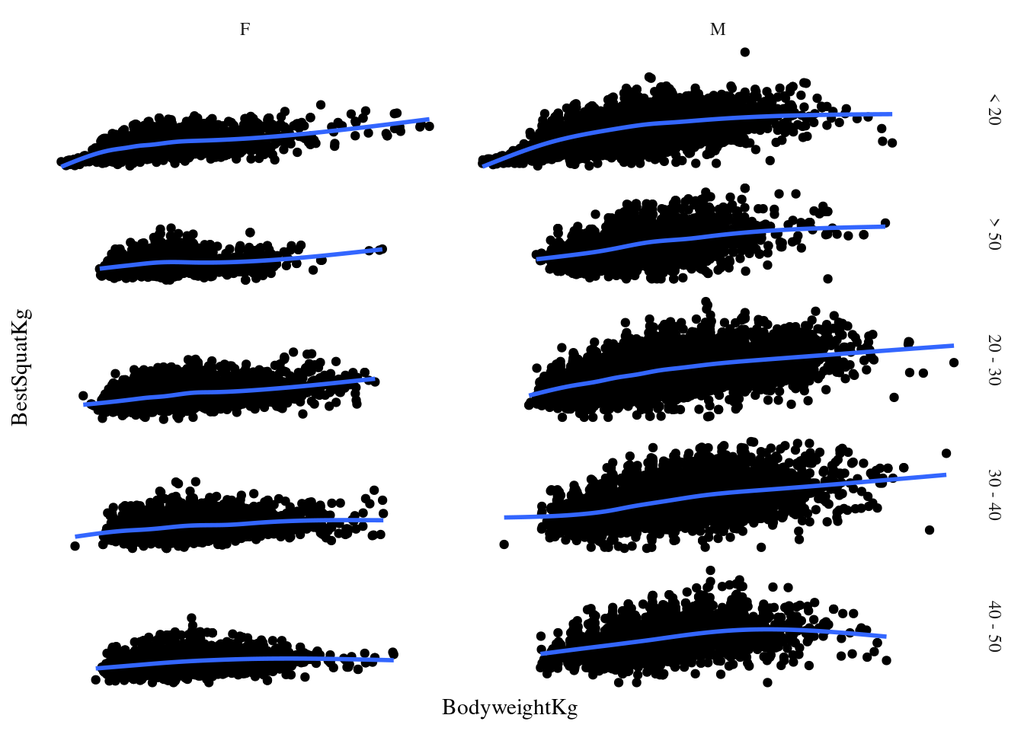

```r
ggplot(combined_data, aes(BodyweightKg, BestSquatKg)) +
  geom_point() +
  geom_smooth(se = FALSE) +
  facet_grid(Age_Bin ~ Sex, scales = 'free', space = 'free') +
  theme_tufte() +
  theme(axis.text = element_blank(), axis.ticks = element_blank())
```

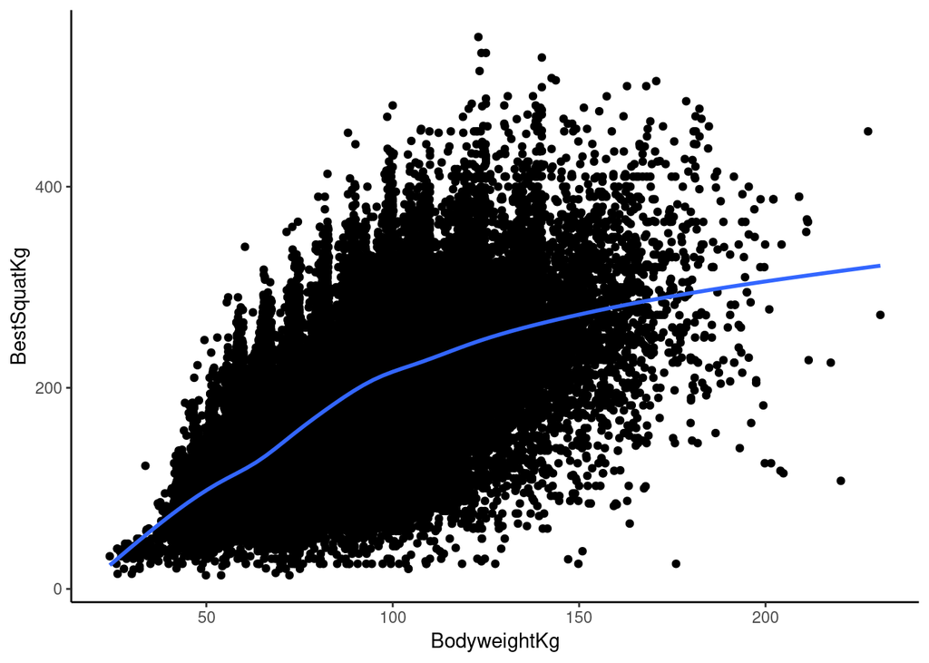

```r
ggplot(combined_data, aes(BodyweightKg, BestSquatKg)) +
  geom_point() +
  geom_smooth(se = FALSE) +
  theme_classic()
```

3a. Recreate the below visualization.

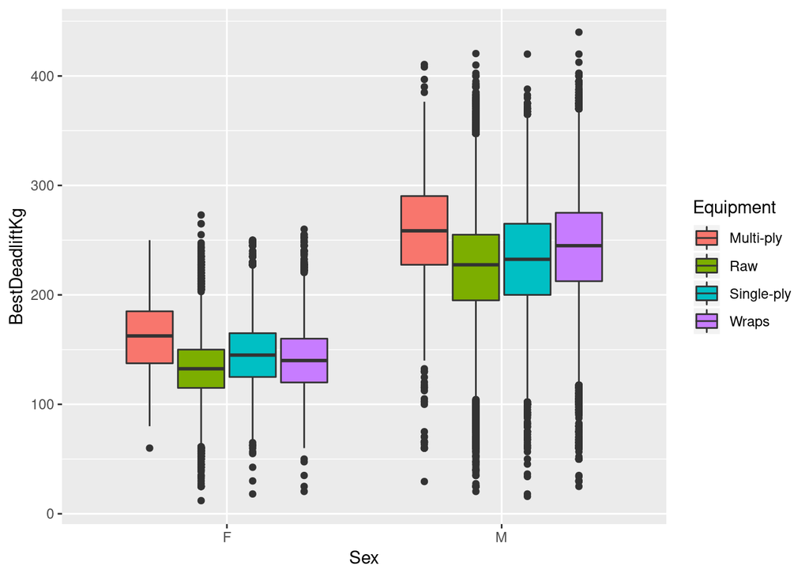

```r
ggplot(combined_data, aes(Sex, BestDeadliftKg, fill = Equipment)) +
  geom_boxplot() +
  theme_grey()
```

3b. Create a visualization which presents the same information, but instead of using the `fill` parameter, uses facetting.

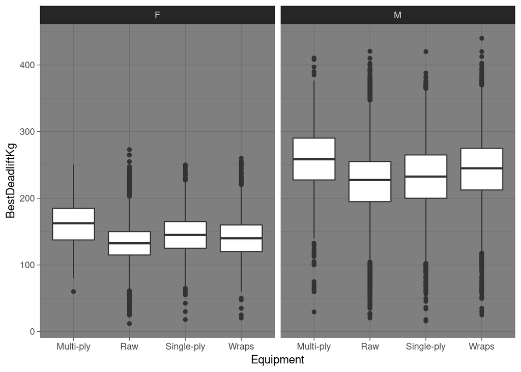

```r
ggplot(combined_data, aes(Equipment, BestDeadliftKg)) +
  geom_boxplot() +
  facet_wrap(~ Sex) +
  theme_dark()
```

4a. Recreate the below visualization.

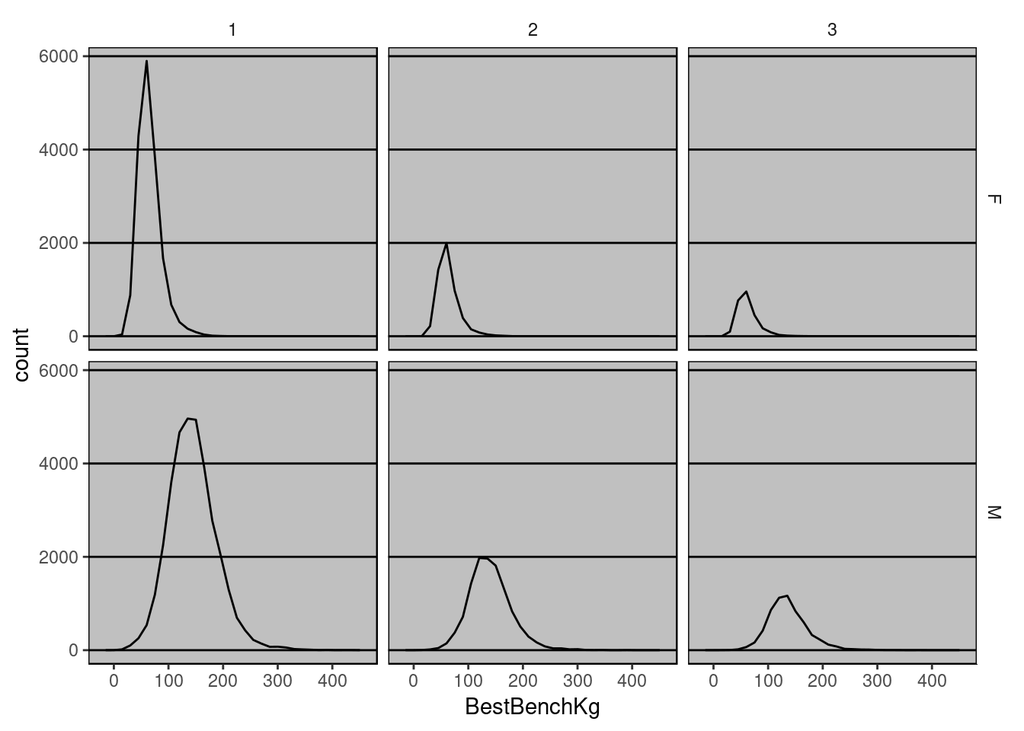

```r
ggplot(top3_placement, aes(BestBenchKg)) +
  geom_freqpoly() +
  facet_grid(Sex ~ Place) +
  theme_excel()
```

4b. Create a visualization which presents the same information, but instead of using facettings, uses the `color` parameter.

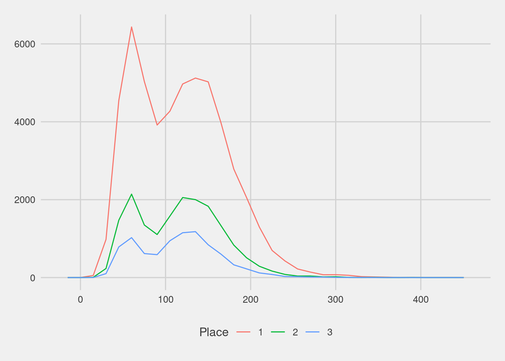

```r
ggplot(top3_placement, aes(BestBenchKg, color = Place)) +
  geom_freqpoly() +
  theme_fivethirtyeight()
```